# Technical Report

Maryam Khan

2/10/2022

## Summary

In this we will be discussing the technical aspects of the project in detail. The purpose of this project is to help a small to mid-sized firm price an apartment that can accommodate 2 – 6 people in **Istanbul**. To make this prediction I will be looking at a few key predictors to make the prediction more accurate. These predictors some basic attributes about the property, reviews and ratings, a few variables regarding the host and various kinds of amenities that describe the apartment. For this project I will be using 5 different types of models which include the OLS, Cart, two different Random Forest and GBM. I will be using these models to pick my final prediction based on the prediction power looking at the RMSE and R squared values.

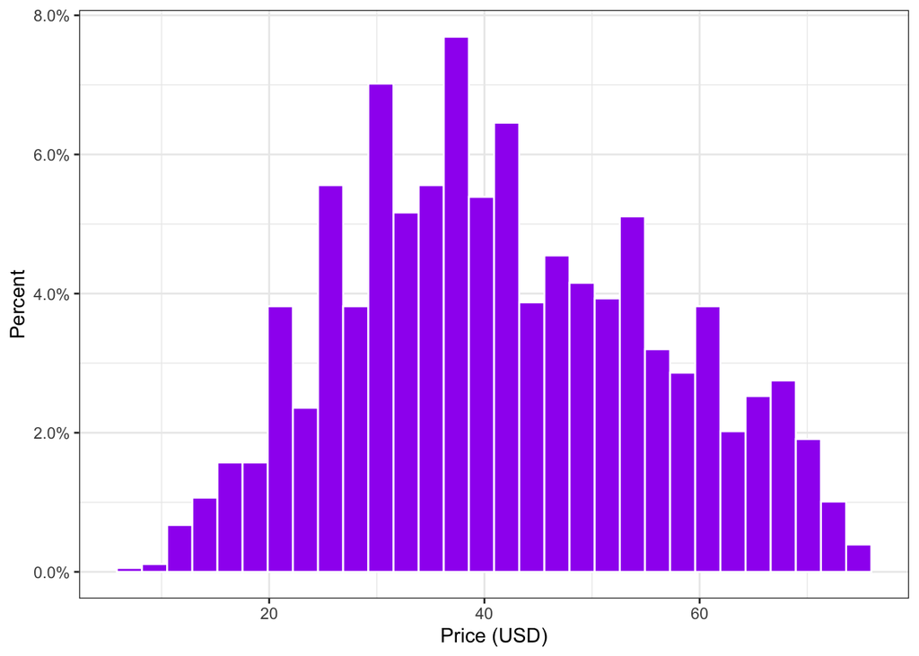

## Data Cleaning

To start working on the models, I had to start with some preliminary cleaning of the data. Before I began cleaning the data my raw data set contained 22,695 observations and 74 variables. I dropped some of the variables in the beginning that included urls and some descriptions that could not be used in the analysis. After doing some rudimentary cleaning I proceeded to sort out the amenities. The amenities required more effort and time in the cleaning process as they were stored in different characters and listing format. For this I first split the amenities in different dummy variables and then they similar amenities were grouped together into one variable for example, the different WIFI and internet variables were all grouped together as one. This helped me in reducing the number of variables, initially, I had 2093 amenities which were reduced to 172 after being grouped together. For more details the data cleaning code has been uploaded here [data_cleaning.R](https://github.com/).

## Data Preparation

The main variable of interest, the price, was also converted to USD as in the raw data the prices were given in Turkish lira. The conversion was 1 USD = 13.56 Turkish Lira. Furthermore, the all the observations with missing price values were dropped. The data was further prepared for the analysis by filtering property type (“f_property_type”). I filtered for apartments, condominium and lofts that can host 2 to 6 people as that is the requirement of our company. Some variables were converted to factors like neighborhoods and property type. Some variables like accommodates, beds and bathrooms had to be converted to numerical values as they were not stored in the correct format. **Imputation** I also imputed some of the variables that contained missing values. Variables like number of bedrooms, bathrooms and the number of beds had missing values. For bedrooms with missing values, it was assumed that there is at least 1 bedroom like in a studio apartment. For the number of beds (“n_beds”), I assumed that the number of accommodates (“n_accommodates”) is highly dependent on this, therefore, I divided the number of accommodates with 1.5 and rounding this to give us the number of beds. After imputation of these predictors, I had a data set which had no missing values. For more details the data preparation code has been uploaded here [data_prep.R](https://github.com/).

## Variables

Another enormous challenge for this project was the future engineering and deciding which variables to include in my modelling. I did this by dividing my variables into groups of 5:

- Numeric variables: These variables define size for example, number of beds, number of accommodates, number of bathrooms and bedrooms, the minimum number of nights required to rent the place and the availability of the apartment in 365 days of the year.
- Factor variables: These are categorical variables that are either in string or numeric form. For example, the neighborhood the apartment is in or the type of property (apartment, condominium, or a loft).
- Dummy variables: These are binary variables mostly describing the amenities of a property like the WIFI, pool, beachfront facing property, kitchen supplies, elevator etc.
- Review variables: These describe the reviews and ratings characteristics for an individual property. Number of reviews, the rating for those reviews and the mean monthly reviews received.
- Host variables: These variables describe the characteristics of the host of the property. They are binary variables like host is a superhost or if the host is verified.

## Exploratory Data Analysis

Once all the data was cleaned and the variables were grouped, we looked at the main target variable which is the price. The price distribution was close to normal, hence, there was no need of taking a log of the variable. The next step was to look for interactions, for this I checked the relationship between property type and some of the amenities and if there was a noticeable price difference then the dummy variable was included as an interaction term with the main indepedent variable of focus which which was property type.

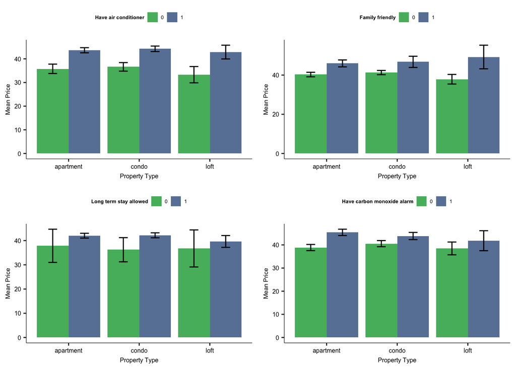

## Cross validation and holdout

Once all the data was prepped for doing our regression analysis, I divided the data into the test and train samples, where 80% of the observations were part of the train sample and 20% of the observations were part of the test sample. These test and train samples were used in all machine learning models.

## LASSO - Variable Selection

I first used LASSO to check variable relation to price and based on that I selected all the non-zero coefficients and included them in my OLS models. The variables with coefficients as 0 were not included as part of the analysis as it showed through the LASSO select that they had no relation to the price of the property.

## Linear Regression

OLS Model Results

| Model | Coefficients | R_squared | BIC | Training_RMSE | Test_RMSE |
| --- | --- | --- | --- | --- | --- |
| M1 | 2 | 0.055 | 11599 | 14.1 | 14.1 |
| M2 | 7 | 0.058 | 11630 | 14.1 | 14.2 |
| M3 | 93 | 0.367 | 11689 | 11.6 | 12.5 |
| M4 | 274 | 0.483 | 12716 | 10.5 | 13.8 |
| LASSO | 117 | 0.264 | NA | NA | 12.5 |

## Random Forest

The Random Forest is a machine learning algorithm that uses regression trees. The software creates hundreds of regression trees and combines them in one and gives an average. Since it uses bootstrap aggregation, the model is able to produce accurate results. For this regression model I will be using the same training and holdout samples that were used for OLS and all other models alongside the tuning parameters with cross validation so that I am able to find the RMSE with lowest possible value.

Random forest RMSE by tuning parameters

| nodes | 8 | 10 | 12 |
| --- | --- | --- | --- |
| 5 | 12.5 | 12.4 | 12.3 |
| 10 | 12.6 | 12.5 | 12.4 |
| 15 | 12.6 | 12.6 | 12.5 |

## Model Selection

Prdictive performance of different models

|  | CV RMSE |
| --- | --- |
| OLS | 12.5 |
| CART | 13.7 |
| Random forest 1: Tuning provided | 12.3 |
| Random forest 2: Auto Tuning | 12.1 |
| GBM | 12.3 |

## Subsample

Performances and subsamples

| Var.1 | RMSE | Mean.price | RMSE.price |
| --- | --- | --- | --- |
| Apartment size | NA | NA | NA |
| large apt | 12.05 | 45.5 | 0.265 |
| small apt | 12.48 | 39.7 | 0.314 |
| Beds | NA | NA | NA |
| 2 | 13.26 | 40.9 | 0.324 |
| 3 | 12.22 | 44.3 | 0.276 |
| 4 | 11.14 | 48.1 | 0.231 |
| 5 | 9.42 | 51.9 | 0.182 |
| 6 | 15.82 | 63.7 | 0.248 |
| 8 | 12.37 | 50.3 | 0.246 |
| Property Type | NA | NA | NA |
| apartment | 12.14 | 42.5 | 0.286 |
| condo | 11.62 | 42.2 | 0.276 |
| loft | 16.35 | 41.0 | 0.399 |
| All | 12.30 | 42.3 | 0.291 |

## Conclusion

After conducting this analysis, according to the results my best model was the Random Forest model with autotuning as that gave the lowest RMSE value. As it can be seen in the graph below, there are some points for which our model predicts the price exactly to what the actual price is. But the model also overfits and underfits as there are points above and below the 45 degree line. To draw a comparison with the case study in Gabor’s book, both the regressions were fairly similar, however my RMSE value was lower as it was around 12 and the RMSE value in the book was around 40 this could be due to many reasons. Firstly, my city was Istanbul and prices in Istanbul and lower compared to prices in London and in recent time the Turkish Lira has depreciated a lot causing the prices in USD to fall as well.

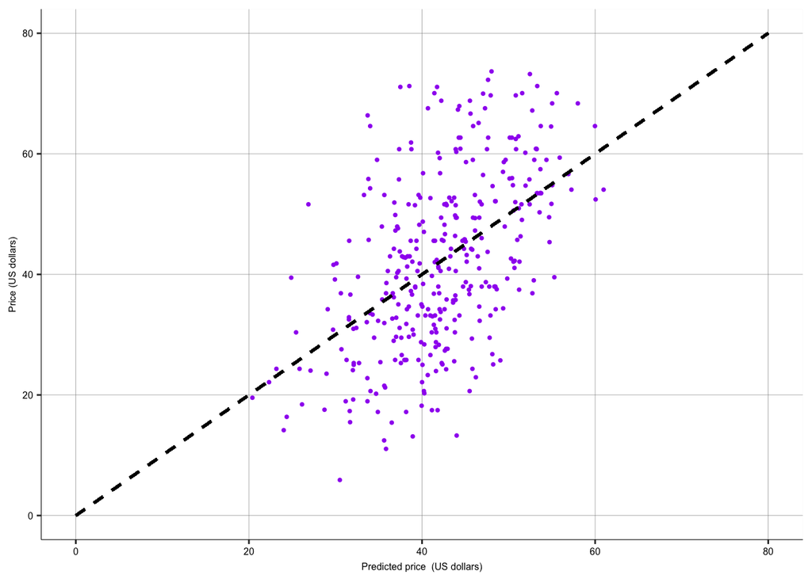